# Data 621 Week Update

MUSA T. GANIYU

July 2, 2016

> Data Exploration:

**Inferential Statistics**

```r
names(crime)
```

```
##  [1] "zn"      "indus"   "chas"    "nox"     "rm"      "age"     "dis"
##  [8] "rad"     "tax"     "ptratio" "black"   "lstat"   "medv"    "target"
```

```r
str(crime)
```

```
## 'data.frame':    466 obs. of  14 variables:
##  $ zn     : num  0 0 0 30 0 0 0 0 0 80 ...
##  $ indus  : num  19.58 19.58 18.1 4.93 2.46 ...
##  $ chas   : int  0 1 0 0 0 0 0 0 0 0 ...
##  $ nox    : num  0.605 0.871 0.74 0.428 0.488 0.52 0.693 0.693 0.515 0.392 ...
##  $ rm     : num  7.93 5.4 6.49 6.39 7.16 ...
##  $ age    : num  96.2 100 100 7.8 92.2 71.3 100 100 38.1 19.1 ...
##  $ dis    : num  2.05 1.32 1.98 7.04 2.7 ...
##  $ rad    : int  5 5 24 6 3 5 24 24 5 1 ...
##  $ tax    : int  403 403 666 300 193 384 666 666 224 315 ...
##  $ ptratio: num  14.7 14.7 20.2 16.6 17.8 20.9 20.2 20.2 20.2 16.4 ...
##  $ black  : num  369 397 387 375 394 ...
##  $ lstat  : num  3.7 26.82 18.85 5.19 4.82 ...
##  $ medv   : num  50 13.4 15.4 23.7 37.9 26.5 5 7 22.2 20.9 ...
##  $ target : int  1 1 1 0 0 0 1 1 0 0 ...
```

```r
dim(crime)
```

```
## [1] 466  14
```

```r
kable(summary(crime))
```

|  | zn | indus | chas | nox | rm | age | dis | rad | tax | ptratio | black | lstat | medv | target |
| --- | --- | --- | --- | --- | --- | --- | --- | --- | --- | --- | --- | --- | --- | --- |
|  | Min. : 0.00 | Min. : 0.460 | Min. :0.00000 | Min. :0.3890 | Min. :3.863 | Min. : 2.90 | Min. : 1.130 | Min. : 1.00 | Min. :187.0 | Min. :12.6 | Min. : 0.32 | Min. : 1.730 | Min. : 5.00 | Min. :0.0000 |
|  | 1st Qu.: 0.00 | 1st Qu.: 5.145 | 1st Qu.:0.00000 | 1st Qu.:0.4480 | 1st Qu.:5.887 | 1st Qu.: 43.88 | 1st Qu.: 2.101 | 1st Qu.: 4.00 | 1st Qu.:281.0 | 1st Qu.:16.9 | 1st Qu.:375.61 | 1st Qu.: 7.043 | 1st Qu.:17.02 | 1st Qu.:0.0000 |
|  | Median : 0.00 | Median : 9.690 | Median :0.00000 | Median :0.5380 | Median :6.210 | Median : 77.15 | Median : 3.191 | Median : 5.00 | Median :334.5 | Median :18.9 | Median :391.34 | Median :11.350 | Median :21.20 | Median :0.0000 |
|  | Mean : 11.58 | Mean :11.105 | Mean :0.07082 | Mean :0.5543 | Mean :6.291 | Mean : 68.37 | Mean : 3.796 | Mean : 9.53 | Mean :409.5 | Mean :18.4 | Mean :357.12 | Mean :12.631 | Mean :22.59 | Mean :0.4914 |
|  | 3rd Qu.: 16.25 | 3rd Qu.:18.100 | 3rd Qu.:0.00000 | 3rd Qu.:0.6240 | 3rd Qu.:6.630 | 3rd Qu.: 94.10 | 3rd Qu.: 5.215 | 3rd Qu.:24.00 | 3rd Qu.:666.0 | 3rd Qu.:20.2 | 3rd Qu.:396.24 | 3rd Qu.:16.930 | 3rd Qu.:25.00 | 3rd Qu.:1.0000 |
|  | Max. :100.00 | Max. :27.740 | Max. :1.00000 | Max. :0.8710 | Max. :8.780 | Max. :100.00 | Max. :12.127 | Max. :24.00 | Max. :711.0 | Max. :22.0 | Max. :396.90 | Max. :37.970 | Max. :50.00 | Max. :1.0000 |

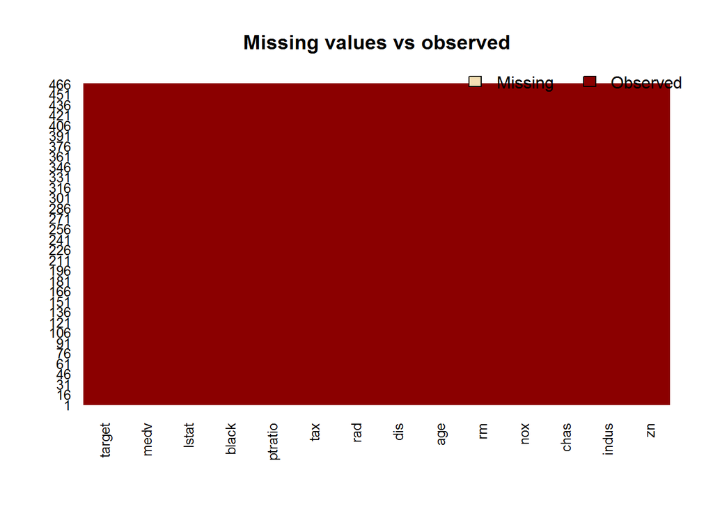

```r
missmap(crime, main = "Missing values vs observed")
```

- The crime dataset contains 14 variables, with 466 observations.
- There are no missing values.
- The Minimum, Quatiles and Maximum values.

> THE ANALYZES
- A plot of Lstat against Zn

```r
plot_ly(data = crime, x = zn , y = lstat, mode = "markers",
        color = "blue", line = list(shape = "linear"))
```

[interactive chart not shown]

> Pairing and fitting the general linear model of Target as a response variance, while other variables serves as an explanatory variable (Independent variable)

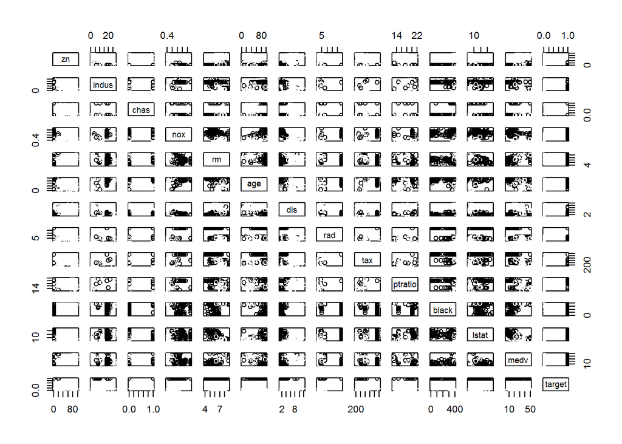

```r
pairs(crime, col=crime$target)
```

```r
fit <- glm(target ~., data = crime)
```

> A summary of the output

```r
summary(fit)
```

```
##
## Call:
## glm(formula = target ~ ., data = crime)
##
## Deviance Residuals:
##      Min        1Q    Median        3Q       Max
## -0.58798  -0.21065  -0.04792   0.14512   0.88772
##
## Coefficients:
##               Estimate Std. Error t value Pr(>|t|)
## (Intercept) -1.5070385  0.3679705  -4.096 4.99e-05 ***
## zn          -0.0009964  0.0009441  -1.055 0.291810
## indus        0.0029792  0.0042907   0.694 0.487828
## chas         0.0082079  0.0588428   0.139 0.889126
## nox          1.9577915  0.2634246   7.432 5.39e-13 ***
## rm           0.0197145  0.0317996   0.620 0.535596
## age          0.0032403  0.0009058   3.577 0.000385 ***
## dis          0.0132690  0.0141501   0.938 0.348886
## rad          0.0199855  0.0043778   4.565 6.44e-06 ***
## tax         -0.0002780  0.0002615  -1.063 0.288451
## ptratio      0.0123980  0.0093702   1.323 0.186462
## black       -0.0002195  0.0001845  -1.190 0.234800
## lstat        0.0042350  0.0038975   1.087 0.277798
## medv         0.0095325  0.0030411   3.135 0.001833 **
## ---
## Signif. codes:  0 '***' 0.001 '**' 0.01 '*' 0.05 '.' 0.1 ' ' 1
##
## (Dispersion parameter for gaussian family taken to be 0.0972825)
##
##     Null deviance: 116.466  on 465  degrees of freedom
## Residual deviance:  43.972  on 452  degrees of freedom
## AIC: 252.39
##
## Number of Fisher Scoring iterations: 2
```

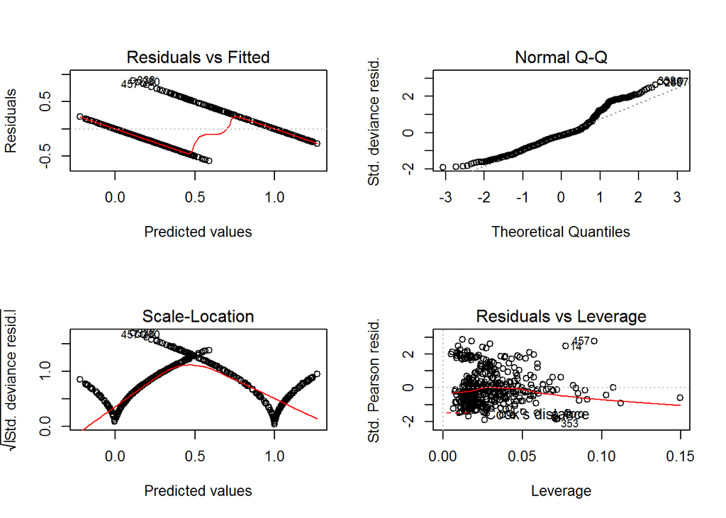

```r
par(mfrow=c(2,2))
plot(fit)
```

> An introduction of Logistics regression for a better results

```r
crimetarget <- glm(target~., family=binomial(link='logit'),data=crime)


summary(crimetarget)
```

```
##
## Call:
## glm(formula = target ~ ., family = binomial(link = "logit"),
##     data = crime)
##
## Deviance Residuals:
##     Min       1Q   Median       3Q      Max
## -2.2854  -0.1372  -0.0017   0.0020   3.4721
##
## Coefficients:
##               Estimate Std. Error z value Pr(>|z|)
## (Intercept) -36.839521   7.028726  -5.241 1.59e-07 ***
## zn           -0.061720   0.034410  -1.794 0.072868 .
## indus        -0.072580   0.048546  -1.495 0.134894
## chas          1.032352   0.759627   1.359 0.174139
## nox          50.159513   8.049503   6.231 4.62e-10 ***
## rm           -0.692145   0.741431  -0.934 0.350548
## age           0.034522   0.013883   2.487 0.012895 *
## dis           0.765795   0.234407   3.267 0.001087 **
## rad           0.663015   0.165135   4.015 5.94e-05 ***
## tax          -0.006593   0.003064  -2.152 0.031422 *
## ptratio       0.442217   0.132234   3.344 0.000825 ***
## black        -0.013094   0.006680  -1.960 0.049974 *
## lstat         0.047571   0.054508   0.873 0.382802
## medv          0.199734   0.071022   2.812 0.004919 **
## ---
## Signif. codes:  0 '***' 0.001 '**' 0.01 '*' 0.05 '.' 0.1 ' ' 1
##
## (Dispersion parameter for binomial family taken to be 1)
##
##     Null deviance: 645.88  on 465  degrees of freedom
## Residual deviance: 186.15  on 452  degrees of freedom
## AIC: 214.15
##
## Number of Fisher Scoring iterations: 9
```

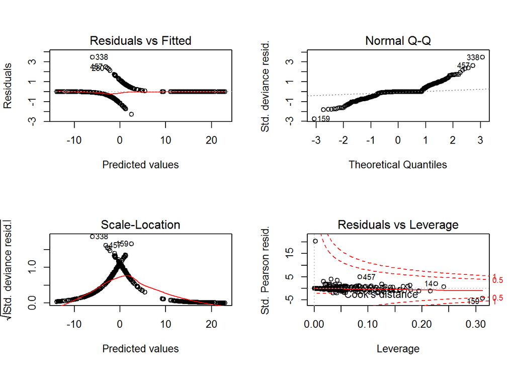

```r
par(mfrow=c(2,2))
plot(crimetarget)
```

**Intrepretations:**

Note that the Null **deviance** is 645.88, which implies that if all other parameters are held constant(control or not included), the estimate would be 645.88, while the Residual deviance of 186.15 means with the imclusion of other estimator, we expect the deviance to be 186.14.

*NB: The greater the difference between the Null deviance and Residual deviance, the better.

```r
anova(crimetarget, test="Chisq")
```

```
## Analysis of Deviance Table
##
## Model: binomial, link: logit
##
## Response: target
##
## Terms added sequentially (first to last)
##
##
##         Df Deviance Resid. Df Resid. Dev  Pr(>Chi)
## NULL                      465     645.88
## zn       1  127.411       464     518.46 < 2.2e-16 ***
## indus    1   86.433       463     432.03 < 2.2e-16 ***
## chas     1    1.274       462     430.76  0.258981
## nox      1  150.804       461     279.95 < 2.2e-16 ***
## rm       1    6.755       460     273.20  0.009349 **
## age      1    0.217       459     272.98  0.641515
## dis      1    7.981       458     265.00  0.004727 **
## rad      1   53.018       457     211.98 3.305e-13 ***
## tax      1    5.562       456     206.42  0.018355 *
## ptratio  1    5.657       455     200.76  0.017388 *
## black    1    4.558       454     196.21  0.032774 *
## lstat    1    0.916       453     195.29  0.338509
## medv     1    9.144       452     186.15  0.002496 **
## ---
## Signif. codes:  0 '***' 0.001 '**' 0.01 '*' 0.05 '.' 0.1 ' ' 1
```

The Analysis of Variance above depicts that the “Zn”, “indus”, “rad” and “noz” contributed significantly to the increment in crime rate in this city under analysis.

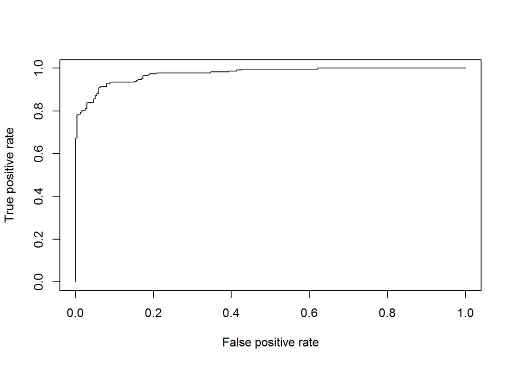

```r
pred <- predict(crimetarget, type="response")
pred2 <- prediction(pred, crime$target)
pred3 <- performance(pred2, measure = "tpr", x.measure = "fpr")
plot(pred3)
```

Above is the plot for Sensitivity and Specitivity for the city target, while the value below is it AUC.

```r
auc <- performance(pred2, measure = "auc")
auc <- auc@y.values[[1]]
auc
```

```
## [1] 0.9752732
```

> Predictions and Accuracy.

```r
target_predicts <- predict(crimetarget,newdata=subset(crime,select=c(1,2,3,4,5,6,7,8,9,10,11,12,13,14)),type='response')
target_predicts <- ifelse(target_predicts > 0.5,1,0)

attach(crime)

table(target_predicts, target)
```

```
##                target
## target_predicts   0   1
##               0 222  20
##               1  15 209
```

```r
misClasificError <- mean(target_predicts != target)
print(paste('Accuracy',1-misClasificError))
```

```
## [1] "Accuracy 0.924892703862661"
```

> CHAS as a response variable.

```r
fit2 <- glm(chas ~., data = crime)
summary(fit2)
```

```
##
## Call:
## glm(formula = chas ~ ., data = crime)
##
## Deviance Residuals:
##      Min        1Q    Median        3Q       Max
## -0.32800  -0.08801  -0.04722  -0.01367   0.94761
##
## Coefficients:
##               Estimate Std. Error t value Pr(>|t|)
## (Intercept) -8.246e-02  2.995e-01  -0.275  0.78320
## zn          -7.013e-05  7.556e-04  -0.093  0.92609
## indus        7.985e-03  3.411e-03   2.341  0.01966 *
## nox          3.113e-01  2.226e-01   1.399  0.16257
## rm          -9.655e-03  2.543e-02  -0.380  0.70430
## age          5.260e-04  7.338e-04   0.717  0.47389
## dis          6.954e-03  1.132e-02   0.614  0.53922
## rad          5.744e-03  3.569e-03   1.609  0.10822
## tax         -4.981e-04  2.080e-04  -2.395  0.01704 *
## ptratio     -7.581e-03  7.496e-03  -1.011  0.31242
## black        1.005e-04  1.476e-04   0.681  0.49628
## lstat       -1.557e-04  3.119e-03  -0.050  0.96021
## medv         6.349e-03  2.439e-03   2.603  0.00954 **
## target       5.244e-03  3.760e-02   0.139  0.88913
## ---
## Signif. codes:  0 '***' 0.001 '**' 0.01 '*' 0.05 '.' 0.1 ' ' 1
##
## (Dispersion parameter for gaussian family taken to be 0.06215705)
##
##     Null deviance: 30.663  on 465  degrees of freedom
## Residual deviance: 28.095  on 452  degrees of freedom
## AIC: 43.646
##
## Number of Fisher Scoring iterations: 2
```

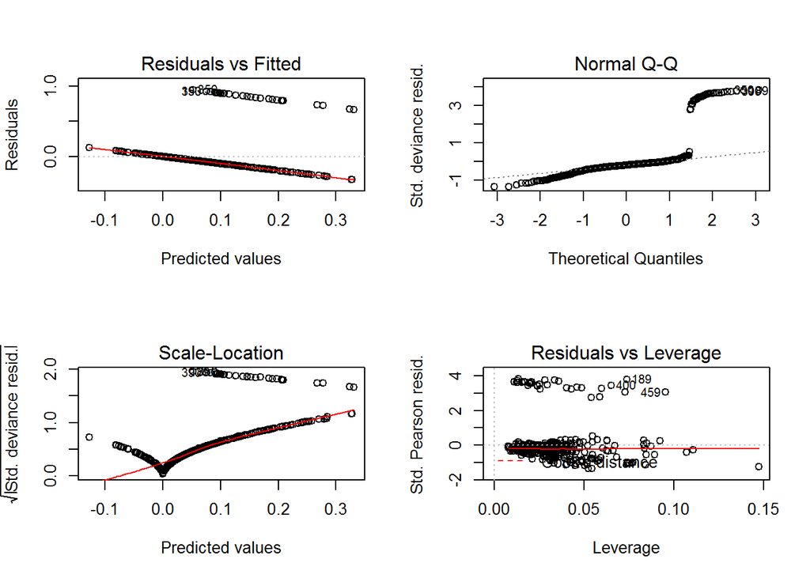

```r
par(mfrow=c(2,2))
plot(fit2)
```

The Above depicts that on “indus”, “tax” and “medv” are staistically significance. We will therefore explore another option: **The Logit.**

```r
crimechas <- glm(chas~., family=binomial(link='logit'),data=crime)
summary(crimechas)
```

```
##
## Call:
## glm(formula = chas ~ ., family = binomial(link = "logit"), data = crime)
##
## Deviance Residuals:
##     Min       1Q   Median       3Q      Max
## -1.0847  -0.3618  -0.2809  -0.1821   2.4811
##
## Coefficients:
##              Estimate Std. Error z value Pr(>|z|)
## (Intercept) -3.308139   5.026203  -0.658  0.51042
## zn          -0.003070   0.013977  -0.220  0.82617
## indus        0.111655   0.046360   2.408  0.01602 *
## nox          4.046547   3.249091   1.245  0.21297
## rm          -0.130162   0.359220  -0.362  0.71709
## age          0.003068   0.012781   0.240  0.81030
## dis          0.057929   0.212968   0.272  0.78561
## rad          0.179719   0.082394   2.181  0.02917 *
## tax         -0.012178   0.004575  -2.662  0.00777 **
## ptratio     -0.114626   0.133580  -0.858  0.39083
## black        0.003234   0.003488   0.927  0.35380
## lstat       -0.010744   0.049840  -0.216  0.82933
## medv         0.059348   0.032227   1.842  0.06553 .
## target       0.384437   0.670299   0.574  0.56629
## ---
## Signif. codes:  0 '***' 0.001 '**' 0.01 '*' 0.05 '.' 0.1 ' ' 1
##
## (Dispersion parameter for binomial family taken to be 1)
##
##     Null deviance: 238.35  on 465  degrees of freedom
## Residual deviance: 203.15  on 452  degrees of freedom
## AIC: 231.15
##
## Number of Fisher Scoring iterations: 6
```

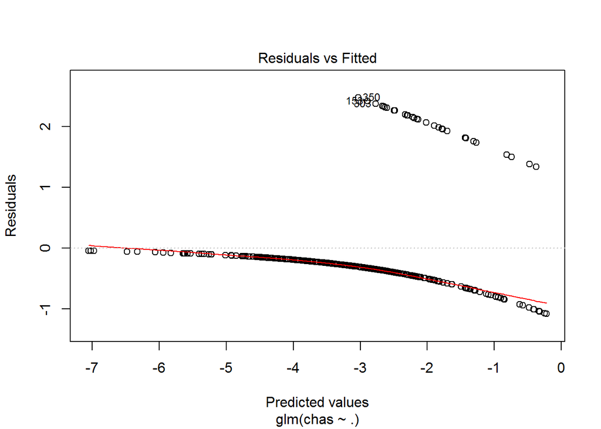

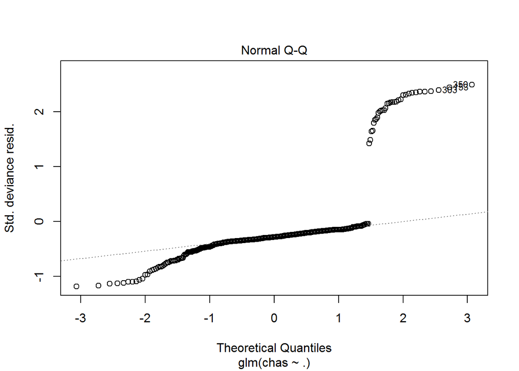

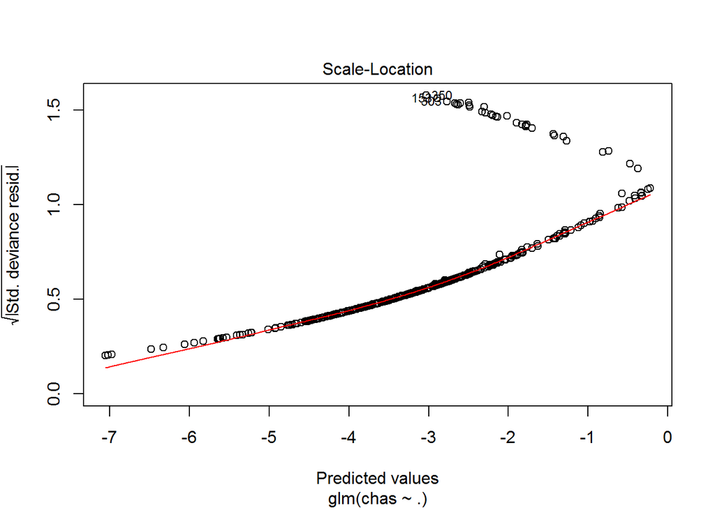

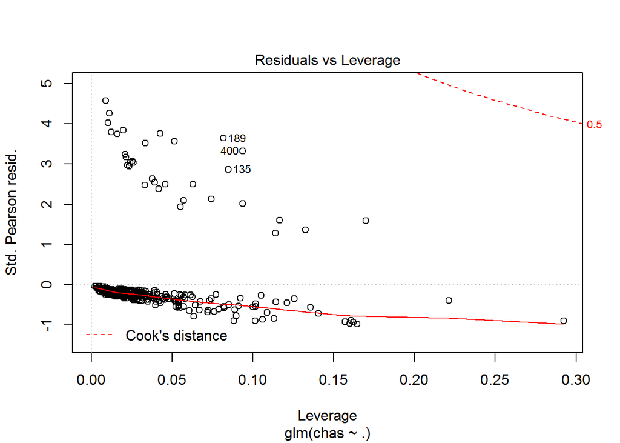

```r
plot(crimechas)
```

On the case of chas a response variable, the Null and Residual deviance are very close. The “Tax”, “rad” and “Indus” have strong association with the crime rate.

```r
anova(crimechas, test="Chisq")
```

```
## Analysis of Deviance Table
##
## Model: binomial, link: logit
##
## Response: chas
##
## Terms added sequentially (first to last)
##
##
##         Df Deviance Resid. Df Resid. Dev Pr(>Chi)
## NULL                      465     238.35
## zn       1   0.8418       464     237.51 0.358879
## indus    1   0.9467       463     236.56 0.330572
## nox      1   2.4413       462     234.12 0.118180
## rm       1   6.6672       461     227.46 0.009821 **
## age      1   0.0579       460     227.40 0.809840
## dis      1   0.5268       459     226.87 0.467938
## rad      1   3.3225       458     223.55 0.068339 .
## tax      1  10.0287       457     213.52 0.001541 **
## ptratio  1   2.9486       456     210.57 0.085953 .
## black    1   2.1110       455     208.46 0.146247
## lstat    1   1.5804       454     206.88 0.208706
## medv     1   3.4047       453     203.47 0.065012 .
## target   1   0.3245       452     203.15 0.568911
## ---
## Signif. codes:  0 '***' 0.001 '**' 0.01 '*' 0.05 '.' 0.1 ' ' 1
```

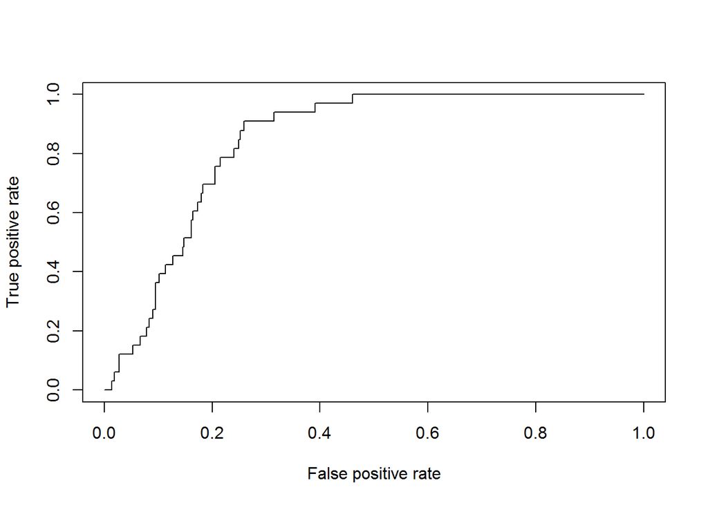

```r
predicts <- predict(crimechas, type="response")
predicts2 <- prediction(predicts, crime$chas)
predicts3 <- performance(predicts2, measure = "tpr", x.measure = "fpr")
plot(predicts3)
```

Above is the Sensitivity and Specitivity plot, while the AUC value is shown below.

```r
auc2 <- performance(predicts2, measure = "auc")
auc2 <- auc2@y.values[[1]]
auc2
```

```
## [1] 0.8426762
```

Below is the prediction for Chas and its Accuracy

```r
chas_predicts <- predict(crimechas,newdata=subset(crime,select=c(1,2,3,4,5,6,7,8,9,10,11,12,13,14)),type='response')
chas_predicts <- ifelse(chas_predicts > 0.5,1,0)

attach(crime)
table(chas_predicts, chas)
```

```
##              chas
## chas_predicts   0   1
##             0 433  33
```

```r
misClasificError <- mean(chas_predicts != chas)
print(paste('Accuracy',1-misClasificError))
```

```
## [1] "Accuracy 0.929184549356223"
```

```r
t <- table(crime[ , c(3,14)])
colnames(t) <- c('Real Positive', 'Real Negative')
rownames(t) <- c('Model Positive', 'Model Negative')
t
```

```
##                 target
## chas             Real Positive Real Negative
##   Model Positive           225           208
##   Model Negative            12            21
```

```r
getConfusionMatrix <- function(df) {
  t <- table(df$chas,df$target)
  colnames(t) <- c('Real Positive', 'Real Negative')
  rownames(t) <- c('Model Positive', 'Model Negative')

  return(t)
}

getAccuracy <- function(df) {
  cm <- getConfusionMatrix(df)

  tn <- cm["Model Negative", "Real Negative"]
  fp <- cm["Model Positive", "Real Negative"]
  fn <- cm["Model Negative", "Real Positive"]
  tp <- cm["Model Positive", "Real Positive"]

  accuracy <- (tn+tp) / (tn+fp+fn+tp)
  return(accuracy)
}

getCER <- function(df) {
  cm <- getConfusionMatrix(df)

  tn <- cm["Model Negative", "Real Negative"]
  fp <- cm["Model Positive", "Real Negative"]
  fn <- cm["Model Negative", "Real Positive"]
  tp <- cm["Model Positive", "Real Positive"]

  cer <- (fp + fn) / (tn+fp+fn+tp)
  return(cer)
}

getPrecision <- function(df) {
  cm <- getConfusionMatrix(df)

  tn <- cm["Model Negative", "Real Negative"]
  fp <- cm["Model Positive", "Real Negative"]
  fn <- cm["Model Negative", "Real Positive"]
  tp <- cm["Model Positive", "Real Positive"]

  precision <- tp / (fp+tp)
  return(precision)

}

getSensitivity <- function(df){
  cm <- getConfusionMatrix(df)

  tn <- cm["Model Negative", "Real Negative"]
  fp <- cm["Model Positive", "Real Negative"]
  fn <- cm["Model Negative", "Real Positive"]
  tp <- cm["Model Positive", "Real Positive"]

  sensitivity <- tp/(tp+fn)

  return(sensitivity)
}

getSpecificity <- function(df){
  cm <- getConfusionMatrix(df)

  tn <- cm["Model Negative", "Real Negative"]
  fp <- cm["Model Positive", "Real Negative"]
  fn <- cm["Model Negative", "Real Positive"]
  tp <- cm["Model Positive", "Real Positive"]

  specificity <- tn / (tn+fp)
  return(specificity)
}

getF1Score <- function(df) {

  cm <- getConfusionMatrix(df)

  tn <- cm["Model Negative", "Real Negative"]
  fp <- cm["Model Positive", "Real Negative"]
  fn <- cm["Model Negative", "Real Positive"]
  tp <- cm["Model Positive", "Real Positive"]

  precision <- getPrecision(df)
  sensitivity <- getSensitivity(df)
  f1score <- 2* (precision * sensitivity) / (precision+sensitivity)

  return(f1score)

}
```

Confusion Matrix

[output not shown]

Accuracy

```r
getAccuracy(crime)
```

```
## [1] 0.527897
```

CER

```r
getCER(crime)
```

```
## [1] 0.472103
```

Precision

```r
getPrecision(crime)
```

```
## [1] 0.5196305
```

F1Score

```r
getF1Score(crime)
```

```
## [1] 0.6716418
```

Specificity

```r
getSpecificity(crime)
```

```
## [1] 0.09170306
```

Sensitivity

```r
getSensitivity(crime);
```

```
## [1] 0.9493671
```